# Unsupervised Learning Project

```python
### Table Styles
styles = [
    dict(selector="tr:hover", props=[("background", "#f4f4f4")]),
    dict(
        selector="th",
        props=[
            ("color", "#fff"),
            ("border", "1px solid #eee"),
            ("padding", "10px 25px"),
            ("border-collapse", "collapse"),
            ("background", "#00cccc"),
            ("text-transform", "uppercase"),
            ("font-size", "18px"),
        ],
    ),
    dict(
        selector="td",
        props=[
            ("color", "#999"),
            ("border", "1px solid #eee"),
            ("padding", "12px 25px"),
            ("border-collapse", "collapse"),
            ("font-size", "15px"),
        ],
    ),
    dict(
        selector="table",
        props=[
            ("font-family", "Arial"),
            ("margin", "20px auto"),
            ("border-collapse", "collapse"),
            ("border", "1px solid #eee"),
            ("border-bottom", "2px solid #00cccc"),
        ],
    ),
    dict(selector="caption", props=[("caption-side", "bottom")]),
]
```

1.1 Load required libraries

```python
# Numerical libraries
import numpy as np

# To handle data in form of rows and columns
import pandas as pd

# Importing Ploting libraries
import matplotlib.pyplot as plt

# To enable plotting graphs in Jupyter notebook
%matplotlib inline

# Importing seaborn for statistical plots
import seaborn as sns



#Preprocessing
#Imputing values
from sklearn.impute import SimpleImputer

#Computes z-score
from scipy.stats import zscore

# Import the StandardScaler Module
from sklearn.preprocessing import StandardScaler,LabelEncoder

# data normalization with sklearn
from sklearn.preprocessing import MinMaxScaler

## Scikit-learn features various classification, regression and clustering algorithms
from sklearn.model_selection import train_test_split

#Clustering
from sklearn.cluster import KMeans

#models
from sklearn import svm

from sklearn.decomposition import PCA

#Hyperparameter tuning
from sklearn.model_selection import GridSearchCV

from sklearn.metrics import classification_report, confusion_matrix, accuracy_score

# To suppress un-necessary warnings
import warnings

warnings.filterwarnings("ignore")
```

PART A | TOTAL | 30

## • DOMAIN: Automobile

## • CONTEXT:

The data concerns city-cycle fuel consumption in miles per gallon to be predicted in terms of 3 multivalued discrete and 5 continuous attributes.

## • DATA DESCRIPTION:

```
## cylinders: multi-valued

## time to accelerate from O to 60 mph (sec.) discrete acceleration: continuous

## engine displacement (cu. inches) displacement: continuous

## model year (modulo 100) model year: multi-valued discrete

## horsepower: continuous

## origin of car  origin: multi-valued discrete

## vehicle weight (lbs.) weight: continuous

## car name: string (unique for each instance)

## MPG (miles per gallon) mpg: continuous
```

## • PROJECT OBJECTIVE:

To understand K-means Clustering by applying on the Car Dataset to segment the cars into various categories.

Steps and Tasks:

1. Data Understanding & Exploration: [5 Marks]

### A. Read ‘Car name.csv’ as a DataFrame and assign it to a variable. [1 Mark]

```python
# Creating the dataframe and import dataset
df_Car_name = pd.read_csv("Car name.csv")
df_Car_name.head().style.set_table_styles(styles).set_caption(
    "Car Name Top 5 records")
```

Car Name Top 5 records

|  | car_name |
| --- | --- |
| 0 | chevrolet chevelle malibu |
| 1 | buick skylark 320 |
| 2 | plymouth satellite |
| 3 | amc rebel sst |
| 4 | ford torino |

### B. Read ‘Car-Attributes.json as a DataFrame and assign it to a variable. [1 Mark]

```python
# Creating the dataframe and import dataset
df_Car_attributes = pd.read_json('Car-Attributes.json')
df_Car_attributes.head().style.set_table_styles(styles).set_caption(
    "Car Attributes Top 5 records")
```

Car Attributes Top 5 records

|  | mpg | cyl | disp | hp | wt | acc | yr | origin |
| --- | --- | --- | --- | --- | --- | --- | --- | --- |
| 0 | 18.000000 | 8 | 307.000000 | 130 | 3504 | 12.000000 | 70 | 1 |
| 1 | 15.000000 | 8 | 350.000000 | 165 | 3693 | 11.500000 | 70 | 1 |
| 2 | 18.000000 | 8 | 318.000000 | 150 | 3436 | 11.000000 | 70 | 1 |
| 3 | 16.000000 | 8 | 304.000000 | 150 | 3433 | 12.000000 | 70 | 1 |
| 4 | 17.000000 | 8 | 302.000000 | 140 | 3449 | 10.500000 | 70 | 1 |

### C. Merge both the DataFrames together to form a single DataFrame [2 Mark]

```python
df_Car =pd.merge(df_Car_name,df_Car_attributes, left_index=True, right_index=True)
```

```python
print(
    "DataFrames",
    "\tRows",
    "\tColumns" "\ndf_Car_name\t",
    df_Car_name.shape[0],
    "\t",
    df_Car_name.shape[1],
    "\n\ndf_Car_attributes",
    df_Car_attributes.shape[0],
    "\t",
    df_Car_attributes.shape[1],
    "\n\ndf_Car\t\t",
    df_Car.shape[0],
    "\t",
    df_Car.shape[1]
)
```

```
DataFrames 	Rows 	Columns
df_Car_name	 398 	 1

df_Car_attributes 398 	 8

df_Car		 398 	 9
```

```python
df_Car.head().style.set_table_styles(styles).set_caption(
    "Car Top 5 records")
```

Car Top 5 records

|  | car_name | mpg | cyl | disp | hp | wt | acc | yr | origin |
| --- | --- | --- | --- | --- | --- | --- | --- | --- | --- |
| 0 | chevrolet chevelle malibu | 18.000000 | 8 | 307.000000 | 130 | 3504 | 12.000000 | 70 | 1 |
| 1 | buick skylark 320 | 15.000000 | 8 | 350.000000 | 165 | 3693 | 11.500000 | 70 | 1 |
| 2 | plymouth satellite | 18.000000 | 8 | 318.000000 | 150 | 3436 | 11.000000 | 70 | 1 |
| 3 | amc rebel sst | 16.000000 | 8 | 304.000000 | 150 | 3433 | 12.000000 | 70 | 1 |
| 4 | ford torino | 17.000000 | 8 | 302.000000 | 140 | 3449 | 10.500000 | 70 | 1 |

Observation:

Training Data:

[output not shown]

Test Data:

[output not shown]

```python
df_Car.info()
```

```
<class 'pandas.core.frame.DataFrame'>
RangeIndex: 398 entries, 0 to 397
Data columns (total 9 columns):
 #   Column    Non-Null Count  Dtype
---  ------    --------------  -----
 0   car_name  398 non-null    object
 1   mpg       398 non-null    float64
 2   cyl       398 non-null    int64
 3   disp      398 non-null    float64
 4   hp        398 non-null    object
 5   wt        398 non-null    int64
 6   acc       398 non-null    float64
 7   yr        398 non-null    int64
 8   origin    398 non-null    int64
dtypes: float64(3), int64(4), object(2)
memory usage: 28.1+ KB
```

```python
# Replacing the categorical variable Origin with actual values
df_Car['origin'] = df_Car['origin'].replace({1:'America',2:'Europe' ,3: 'Asia'})
```

```python
# Convert categorical variable into dummy/indicator variables. As many columns will be created as distinct values
# This is also kown as one hot coding. The column names will be America, Europe and Asia... with one hot coding
df_Car = pd.get_dummies(df_Car, columns=['origin'])
```

```python
df_Car.sample(5).style.set_table_styles(styles).set_caption(
    "Car random 5 records")
```

Car random 5 records

|  | car_name | mpg | cyl | disp | hp | wt | acc | yr | origin_America | origin_Asia | origin_Europe |
| --- | --- | --- | --- | --- | --- | --- | --- | --- | --- | --- | --- |
| 278 | volkswagen scirocco | 31.500000 | 4 | 89.000000 | 71 | 1990 | 14.900000 | 78 | 0 | 0 | 1 |
| 30 | chevrolet vega 2300 | 28.000000 | 4 | 140.000000 | 90 | 2264 | 15.500000 | 71 | 1 | 0 | 0 |
| 240 | volkswagen dasher | 30.500000 | 4 | 97.000000 | 78 | 2190 | 14.100000 | 77 | 0 | 0 | 1 |
| 31 | toyota corona | 25.000000 | 4 | 113.000000 | 95 | 2228 | 14.000000 | 71 | 0 | 1 | 0 |
| 326 | vw dasher (diesel) | 43.400000 | 4 | 90.000000 | 48 | 2335 | 23.700000 | 80 | 0 | 0 | 1 |

```python
df_Car.car_name.value_counts()
```

```
ford pinto              6
amc matador             5
toyota corolla          5
ford maverick           5
toyota corona           4
                       ..
mercury marquis         1
datsun 810              1
datsun 510 (sw)         1
ford fairmont (auto)    1
volkswagen 411 (sw)     1
Name: car_name, Length: 305, dtype: int64
```

### D. Print 5 point summary of the numerical features and share insights. [1 Marks]

```python
df_Car.describe().transpose().style.set_table_styles(styles).set_caption("5 Point Summary").highlight_max().highlight_null(null_color="red")
```

5 Point Summary

|  | count | mean | std | min | 25% | 50% | 75% | max |
| --- | --- | --- | --- | --- | --- | --- | --- | --- |
| mpg | 398.000000 | 23.514573 | 7.815984 | 9.000000 | 17.500000 | 23.000000 | 29.000000 | 46.600000 |
| cyl | 398.000000 | 5.454774 | 1.701004 | 3.000000 | 4.000000 | 4.000000 | 8.000000 | 8.000000 |
| disp | 398.000000 | 193.425879 | 104.269838 | 68.000000 | 104.250000 | 148.500000 | 262.000000 | 455.000000 |
| wt | 398.000000 | 2970.424623 | 846.841774 | 1613.000000 | 2223.750000 | 2803.500000 | 3608.000000 | 5140.000000 |
| acc | 398.000000 | 15.568090 | 2.757689 | 8.000000 | 13.825000 | 15.500000 | 17.175000 | 24.800000 |
| yr | 398.000000 | 76.010050 | 3.697627 | 70.000000 | 73.000000 | 76.000000 | 79.000000 | 82.000000 |
| origin_America | 398.000000 | 0.625628 | 0.484569 | 0.000000 | 0.000000 | 1.000000 | 1.000000 | 1.000000 |
| origin_Asia | 398.000000 | 0.198492 | 0.399367 | 0.000000 | 0.000000 | 0.000000 | 0.000000 | 1.000000 |
| origin_Europe | 398.000000 | 0.175879 | 0.381197 | 0.000000 | 0.000000 | 0.000000 | 0.000000 | 1.000000 |

```python
# horsepower(hp) column is missing cause it does not seem to be reqcognized as a numerical column! : its object
df_Car.dtypes
```

```
car_name           object
mpg               float64
cyl                 int64
disp              float64
hp                 object
wt                  int64
acc               float64
yr                  int64
origin_America      uint8
origin_Asia         uint8
origin_Europe       uint8
dtype: object
```

2. Data Preparation & Analysis: [10 Marks]

### A. Check and print feature-wise percentage of missing values present in the data and impute with the best suitable approach. [2 Mark]

```python
# the total percentage of the missing values.
total = df_Car.isnull().sum().sort_values(ascending=False)
percent = round(total / len(df_Car) * 100, 2)
pd.concat([total, percent], axis=1, keys=["Total", "Percent"]).style.set_table_styles(styles).set_caption("Feature-wise percentage of missing values")
```

Feature-wise percentage of missing values

|  | Total | Percent |
| --- | --- | --- |
| car_name | 0 | 0.000000 |
| mpg | 0 | 0.000000 |
| cyl | 0 | 0.000000 |
| disp | 0 | 0.000000 |
| hp | 0 | 0.000000 |
| wt | 0 | 0.000000 |
| acc | 0 | 0.000000 |
| yr | 0 | 0.000000 |
| origin_America | 0 | 0.000000 |
| origin_Asia | 0 | 0.000000 |
| origin_Europe | 0 | 0.000000 |

It is showing that we don’t have any null values in our dataset

### B. Check for duplicate values in the data and impute with the best suitable approach. [1 Mark]

```python
#Selecting duplicate rows occurrence based on all columns
duplicate = df_Car.duplicated().sum()
if duplicate > 0:
    # Print the resultant Dataframe
    print("Duplicate Rows :\n", duplicate)
else :
    print("No Duplicate records found")
```

```
No Duplicate records found
```

```python
#droping / ignoring car name as it has not use in building model
df_Car = df_Car.drop('car_name',axis = 1)
```

### C. Plot a pairplot for all features. [1 Marks]

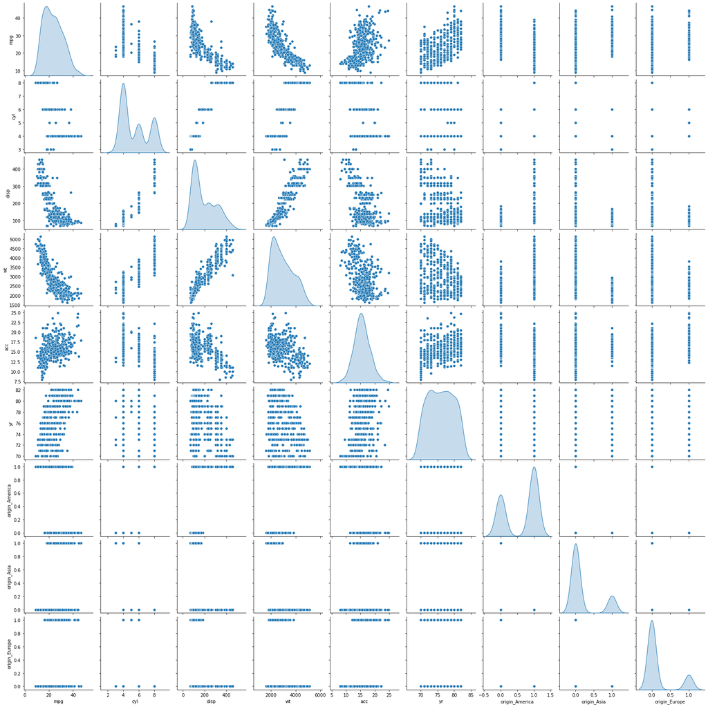

```python
sns.pairplot(data=df_Car, diag_kind="kde", palette="Set1")
```

# Observations

- From diagonal plots we can see origin has 3 points (evident from data)
- yr - shows two peaks majorily
- acc,mpg are nearly normal
- cyl and disp shows 3 clusters while wt shows 2
- from bivariate plots we can see that mps shows negative liner relationship with wt and disp

```python
# sorts all correlations with ascending sort.
df_Car.corr().unstack().sort_values().drop_duplicates()
```

```
mpg             wt               -0.831741
                disp             -0.804203
                cyl              -0.775396
origin_Asia     origin_America   -0.643317
origin_Europe   origin_America   -0.597198
origin_America  mpg              -0.568192
acc             disp             -0.543684
                cyl              -0.505419
wt              origin_Asia      -0.440817
disp            origin_Asia      -0.433505
wt              acc              -0.417457
origin_Asia     cyl              -0.396479
origin_Europe   disp             -0.373886
yr              disp             -0.370164
cyl             origin_Europe    -0.352861
                yr               -0.348746
wt              yr               -0.306564
                origin_Europe    -0.298843
origin_America  acc              -0.250806
origin_Europe   origin_Asia      -0.229895
origin_America  yr               -0.139883
yr              origin_Europe    -0.024489
acc             origin_Asia       0.109144
yr              origin_Asia       0.193101
acc             origin_Europe     0.204473
mpg             origin_Europe     0.259022
yr              acc               0.288137
acc             mpg               0.420289
origin_Asia     mpg               0.442174
mpg             yr                0.579267
origin_America  wt                0.598398
cyl             origin_America    0.604351
disp            origin_America    0.651407
cyl             wt                0.896017
wt              disp              0.932824
disp            cyl               0.950721
mpg             mpg               1.000000
dtype: float64
```

### D. Visualize a scatterplot for ‘wt’ and ‘disp’. Datapoints should be distinguishable by ‘cyl’. [1 Marks]

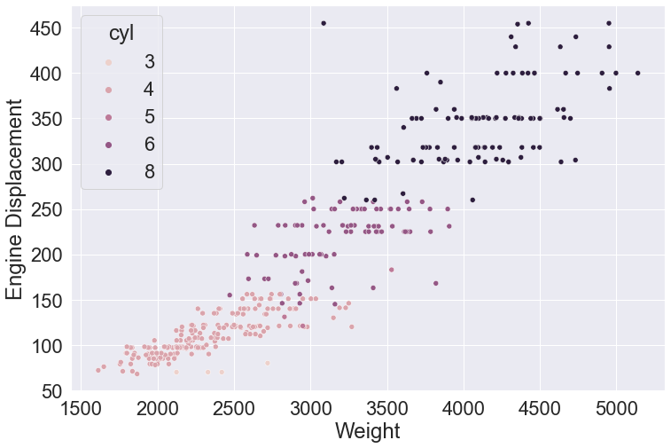

```python
fig = plt.gcf()

# Change seaborn plot size
fig.set_size_inches(12, 8)
sns.set(style="ticks")
# Setting the font scale
sns.set(font_scale=2)
sns.scatterplot(x='wt',y='disp',hue="cyl",data=df_Car)
plt.xlabel('Weight')
plt.ylabel('Engine Displacement')
plt.show()
```

### E. Share insights for Q2.d. [1 Marks]

- There is strong positive corelation between weight and displacement 93%
- There is strong positive corelation between cyl and displacement 95%
- as cylinders increases displacement increases in polynomial order.
- as cylinders increases vehicle's weight increases on average
- the vehicles with more cylinders have more weight and hence less acceleration.

### F. Visualize a scatterplot for ‘wt’ and ’mpg’. Datapoints should be distinguishable by ‘cyl’. [1 Marks]

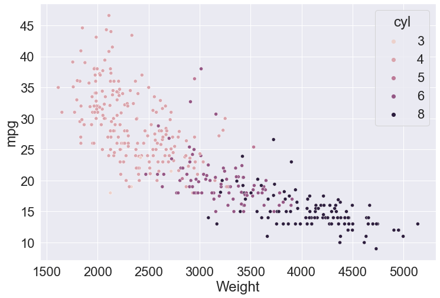

```python
fig = plt.gcf()

# Change seaborn plot size
fig.set_size_inches(12, 8)
sns.set(style="ticks")
# Setting the font scale
sns.set(font_scale=2)
sns.scatterplot(x='wt',y='mpg',hue="cyl",data=df_Car)
plt.xlabel('Weight')
plt.ylabel('mpg')
plt.show()
```

### G. Share insights for Q2.f. [1 Marks]

- There is strong negative corelation between weight and mpg -83%
- There is strong negative corelation between cyl and mpg -77%
- as mpg_level increases weight decreases and acceleration increases.
- vehicles with low mpg has high weight .
- vehicles with more cylinders has high weight .

### H. Check for unexpected values in all the features and datapoints with such values. [2 Marks]

```python
# Check for space in any columns
df_Car["hp"].str.isspace().sum()
```

```
0
```

```python
df_Car["hp"].unique()
```

```
array([130, 165, 150, 140, 198, 220, 215, 225, 190, 170, 160, 95, 97, 85,
       88, 46, 87, 90, 113, 200, 210, 193, '?', 100, 105, 175, 153, 180,
       110, 72, 86, 70, 76, 65, 69, 60, 80, 54, 208, 155, 112, 92, 145,
       137, 158, 167, 94, 107, 230, 49, 75, 91, 122, 67, 83, 78, 52, 61,
       93, 148, 129, 96, 71, 98, 115, 53, 81, 79, 120, 152, 102, 108, 68,
       58, 149, 89, 63, 48, 66, 139, 103, 125, 133, 138, 135, 142, 77, 62,
       132, 84, 64, 74, 116, 82], dtype=object)
```

### Observed "?" in the data and we have to impute this data

```python
# isdigit()? on 'horsepower'
hpIsDigit = pd.DataFrame(df_Car['hp'].str.isdigit()) # if the string is made of digits store True else False

#print isDigit = False!
df_Car[hpIsDigit['hp'] == False]# from temp take only those rows where hp has false
```

|  | mpg | cyl | disp | hp | wt | acc | yr | origin_America | origin_Asia | origin_Europe |
| --- | --- | --- | --- | --- | --- | --- | --- | --- | --- | --- |
| 32 | 25.0 | 4 | 98.0 | ? | 2046 | 19.0 | 71 | 1 | 0 | 0 |
| 126 | 21.0 | 6 | 200.0 | ? | 2875 | 17.0 | 74 | 1 | 0 | 0 |
| 330 | 40.9 | 4 | 85.0 | ? | 1835 | 17.3 | 80 | 0 | 0 | 1 |
| 336 | 23.6 | 4 | 140.0 | ? | 2905 | 14.3 | 80 | 1 | 0 | 0 |
| 354 | 34.5 | 4 | 100.0 | ? | 2320 | 15.8 | 81 | 0 | 0 | 1 |
| 374 | 23.0 | 4 | 151.0 | ? | 3035 | 20.5 | 82 | 1 | 0 | 0 |

```python
# Missing values have a'?''
# Replace missing values with NaN

df_Car= df_Car.replace('?' , np.nan)
df_Car[hpIsDigit['hp'] == False]
```

|  | mpg | cyl | disp | hp | wt | acc | yr | origin_America | origin_Asia | origin_Europe |
| --- | --- | --- | --- | --- | --- | --- | --- | --- | --- | --- |
| 32 | 25.0 | 4 | 98.0 | NaN | 2046 | 19.0 | 71 | 1 | 0 | 0 |
| 126 | 21.0 | 6 | 200.0 | NaN | 2875 | 17.0 | 74 | 1 | 0 | 0 |
| 330 | 40.9 | 4 | 85.0 | NaN | 1835 | 17.3 | 80 | 0 | 0 | 1 |
| 336 | 23.6 | 4 | 140.0 | NaN | 2905 | 14.3 | 80 | 1 | 0 | 0 |
| 354 | 34.5 | 4 | 100.0 | NaN | 2320 | 15.8 | 81 | 0 | 0 | 1 |
| 374 | 23.0 | 4 | 151.0 | NaN | 3035 | 20.5 | 82 | 1 | 0 | 0 |

### Replace missing values with median values

### Of 398 rows 6 have NAN in the hp column.

### Also convert hp column datatype "object to float"

```python
# replace the missing values with median value.
df_Car = df_Car.apply((lambda x: x.fillna(x.median())),axis=0)

# converting the hp column from object type to float
df_Car['hp'] = df_Car['hp'].astype('float64')
```

3. Clustering: [5 Marks]

### A. Apply K-Means clustering for 2 to 10 clusters. [3 Marks]

```python
#Scale the data - compute z-score
df_Car_z = df_Car.apply(zscore)
```

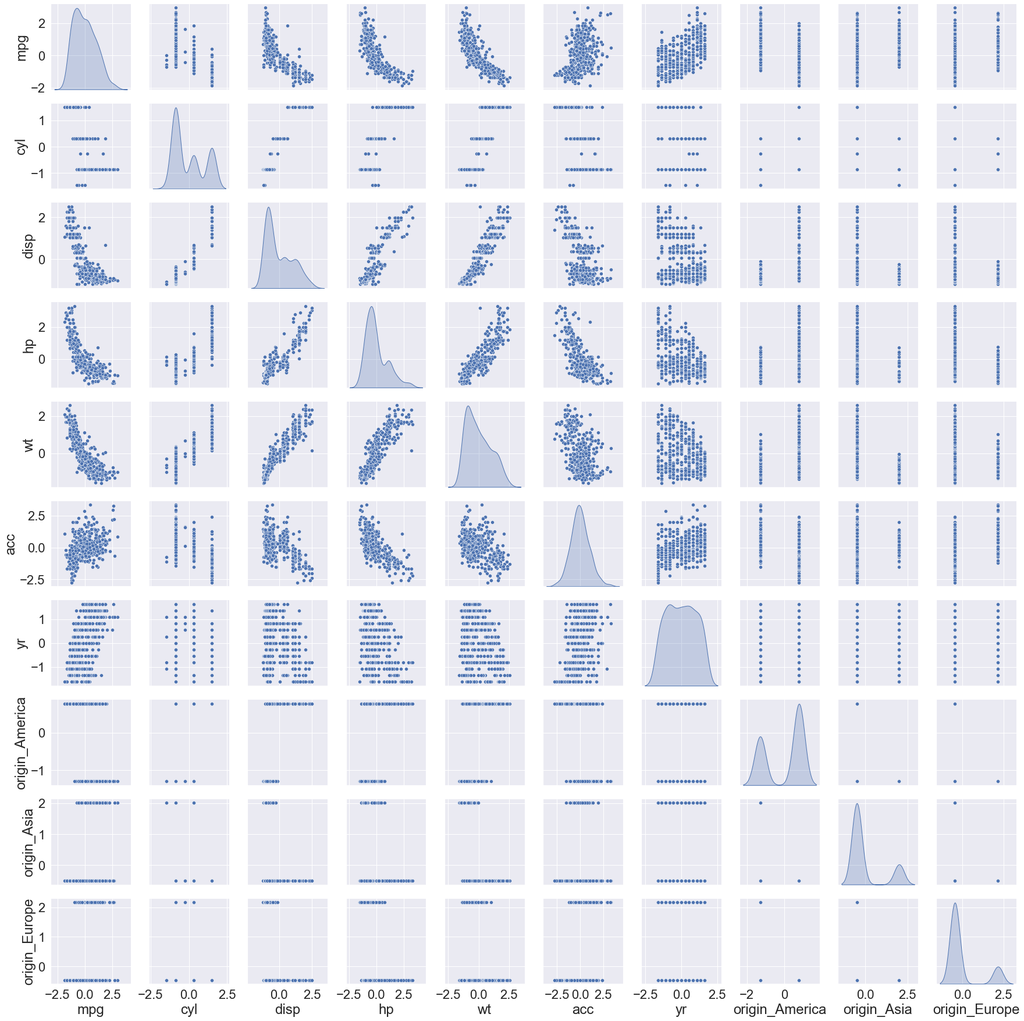

```python
sns.pairplot(df_Car_z,diag_kind='kde')
```

### Based on the kde plots, we can work with 2 or 3 clusters

```python
#Finding optimal no. of clusters
from scipy.spatial.distance import cdist
clusters=range(2,11)
meanDistortions=[]

for k in clusters:
    model=KMeans(n_clusters=k)
    model.fit(df_Car_z)
    prediction=model.predict(df_Car_z)
    meanDistortions.append(sum(np.min(cdist(df_Car_z, model.cluster_centers_, 'euclidean'), axis=1)) / df_Car_z.shape[0])
```

```python
meanDistortions
```

```
[2.284346590705216,
 1.9203409794913435,
 1.5944635369271296,
 1.428105843786903,
 1.3559148761107485,
 1.2996802960434348,
 1.2369670883993544,
 1.1816193997541085,
 1.1343207278676506]
```

### B. Plot a visual and find elbow point. [2 Marks]

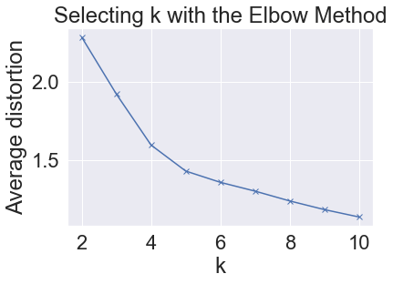

```python
plt.plot(clusters, meanDistortions, 'bx-')
plt.xlabel('k')
plt.ylabel('Average distortion')
plt.title('Selecting k with the Elbow Method')
```

### C. On the above visual, highlight which are the possible Elbow points. [1 Marks]

The bend is coming out clearly .There is bend at 4 cluster

Elbow points are 4 and 5 elbow points

### D. Train a K-means clustering model once again on the optimal number of clusters. [3 Marks]

```python
# Let us first start with K = 4
final_model=KMeans(4)
final_model.fit_transform(df_Car_z)
```

```
array([[5.70945792, 3.58974274, 1.61327583, 5.50323653],
       [6.35003998, 4.30753373, 1.2276512 , 6.13428766],
       [5.97237827, 3.9672787 , 1.55457511, 5.78917181],
       ...,
       [3.87197307, 2.71853528, 5.32726928, 4.23059712],
       [3.63495621, 1.91405377, 5.51122983, 3.80612007],
       [3.71957799, 2.16058047, 5.6991029 , 3.89540645]])
```

### E. Add a new feature in the DataFrame which will have labels based upon cluster value. [2 Marks]

```python
#Getting the Centroids
centroids = final_model.cluster_centers_
label = final_model.predict(df_Car_z)
u_labels = np.unique(label)

#Append the prediction
df_Car_z["Labels"] = final_model.predict(df_Car_z)
print("Labels Assigned : \n")
df_Car_z.sample(5)
```

```
Labels Assigned :
```

|  | mpg | cyl | disp | hp | wt | acc | yr | origin_America | origin_Asia | origin_Europe | Labels |
| --- | --- | --- | --- | --- | --- | --- | --- | --- | --- | --- | --- |
| 87 | -1.346959 | 1.498191 | 1.503514 | 1.066049 | 1.203125 | -0.932419 | -0.815074 | 0.773559 | -0.497643 | -0.461968 | 2 |
| 107 | -0.706439 | 0.320935 | 0.370411 | -0.112746 | -0.214506 | -0.206262 | -0.815074 | 0.773559 | -0.497643 | -0.461968 | 1 |
| 81 | 0.574601 | -0.856321 | -0.925936 | -0.322309 | -0.806861 | 0.519896 | -1.085858 | -1.292726 | 2.009471 | -0.461968 | 0 |
| 52 | 0.830809 | -0.856321 | -1.012360 | -0.741436 | -1.070524 | -0.387801 | -1.356642 | -1.292726 | -0.497643 | 2.164651 | 3 |
| 96 | -1.346959 | 1.498191 | 1.599540 | 1.851913 | 1.005673 | -1.658577 | -0.815074 | 0.773559 | -0.497643 | -0.461968 | 2 |

### F. Plot a visual and color the datapoints based upon clusters. [2 Marks]

[output not shown]

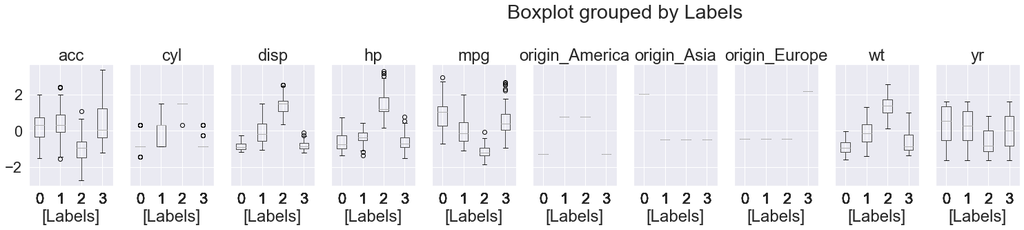

```python
df_Car_z.boxplot(by='Labels',  layout=(4,12),figsize=(30,15))
```

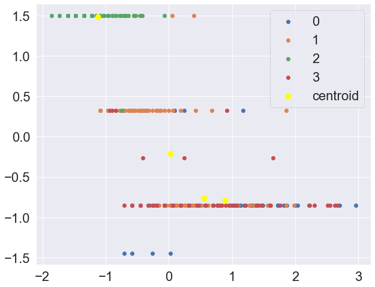

```python
#plotting the results:
fig = plt.figure(figsize=(10, 8))
for i in u_labels:
    plt.scatter(df_Car_z.iloc[label == i , 0] , df_Car_z.iloc[label == i , 1] , label = i)
plt.scatter(centroids[:,0] , centroids[:,1] , s = 80, color = "yellow",label="centroid")
plt.legend()
plt.show()
```

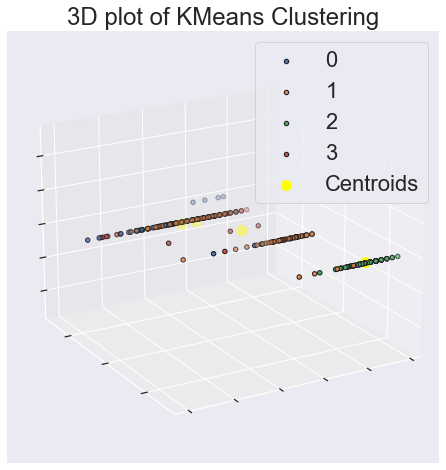

```python
from mpl_toolkits.mplot3d import Axes3D
## 3D plots of clusters
fig = plt.figure(figsize=(8, 6))
ax = Axes3D(fig, rect=[0, 0, .95, 1], elev=20, azim=60)

labels = final_model.labels_
#ax.scatter(df_Car_z.iloc[:, 0], df_Car_z.iloc[:, 1], df_Car_z.iloc[:, 2],c=labels.astype(np.float), edgecolor='k')
for i in u_labels:
    ax.scatter(df_Car_z.iloc[label == i , 0] , df_Car_z.iloc[label == i , 1] , label = i, edgecolor='k')
plt.scatter(final_model.cluster_centers_[:,0],final_model.cluster_centers_[:,1],s=100,c='yellow',label='Centroids')
ax.w_xaxis.set_ticklabels([])
ax.w_yaxis.set_ticklabels([])
ax.w_zaxis.set_ticklabels([])

ax.set_title('3D plot of KMeans Clustering')
plt.legend()
```

### G. Pass a new DataPoint and predict which cluster it belongs to. [2 Marks]

```python
# initialize list of lists
data = [[14.0, 6, 455.0, 225.0, 3086, 10.0, 70, 1, 0, 0],
        [16.0,	8, 400.0, 230.0, 4278, 9.5, 73, 0, 1, 0],
        [14.0,	6, 455.0, 225.0, 4425, 10.0, 70, 1, 0, 0],
        [14	,  4,  121.0, 113.0, 2234, 12.5, 70, 0, 0, 1],
        [14.0,	8, 454.0, 220.0, 4354, 9.0, 70, 1, 0, 0]]

# Create the df_Car_new DataFrame
df_Car_new = pd.DataFrame(data, columns=[
                          "mpg", "cyl",	"disp",	"hp", "wt",	"acc", "yr","origin_America",	"origin_Asia",	"origin_Europe"])

df_Car_new
```

|  | mpg | cyl | disp | hp | wt | acc | yr | origin_America | origin_Asia | origin_Europe |
| --- | --- | --- | --- | --- | --- | --- | --- | --- | --- | --- |
| 0 | 14.0 | 6 | 455.0 | 225.0 | 3086 | 10.0 | 70 | 1 | 0 | 0 |
| 1 | 16.0 | 8 | 400.0 | 230.0 | 4278 | 9.5 | 73 | 0 | 1 | 0 |
| 2 | 14.0 | 6 | 455.0 | 225.0 | 4425 | 10.0 | 70 | 1 | 0 | 0 |
| 3 | 14.0 | 4 | 121.0 | 113.0 | 2234 | 12.5 | 70 | 0 | 0 | 1 |
| 4 | 14.0 | 8 | 454.0 | 220.0 | 4354 | 9.0 | 70 | 1 | 0 | 0 |

```python
#Scale the data - compute z-score
df_Car_new_z = df_Car_new.apply(zscore)

#with K = 4
#final_model.fit_transform(df_Car_new_z)

#Append the prediction
df_Car_new_z["Labels"] = final_model.predict(df_Car_new_z)

print("Labels Assigned : \n")
df_Car_new_z.sample(5)
```

```
Labels Assigned :
```

|  | mpg | cyl | disp | hp | wt | acc | yr | origin_America | origin_Asia | origin_Europe | Labels |
| --- | --- | --- | --- | --- | --- | --- | --- | --- | --- | --- | --- |
| 1 | 2.0 | 1.069045 | 0.177278 | 0.610089 | 0.690272 | -0.579324 | 2.0 | -1.224745 | 2.0 | -0.5 | 0 |
| 3 | -0.5 | -1.603567 | -1.973181 | -1.995036 | -1.651109 | 1.903494 | -0.5 | -1.224745 | -0.5 | 2.0 | 3 |
| 0 | -0.5 | -0.267261 | 0.601204 | 0.498759 | -0.675151 | -0.165521 | -0.5 | 0.816497 | -0.5 | -0.5 | 1 |
| 2 | -0.5 | -0.267261 | 0.601204 | 0.498759 | 0.858659 | -0.165521 | -0.5 | 0.816497 | -0.5 | -0.5 | 1 |
| 4 | -0.5 | 1.069045 | 0.593496 | 0.387429 | 0.777329 | -0.993127 | -0.5 | 0.816497 | -0.5 | -0.5 | 2 |

### Above data shows the 5 datapoints belongs to which cluster

PART B | TOTAL | 30

## DOMAIN: Automobile

## CONTEXT:

The purpose is to classify a given silhouette as one of three types of vehicle, using a set of features extracted from the silhouette. The vehicle may be viewed from one of many different angles.

## DATA DESCRIPTION:

The data contains features extracted from the silhouette of vehicles in different angles.

Four "Corgie" model vehicles were used for the experiment:

```
a double decker bus,

Cheverolet van,

Saab 9000 and

an Opel Manta 400 cars.
```

This particular combination of vehicles was chosen with the expectation that the bus, van and either one of the cars would be readily distinguishable, but it would be more difficult to distinguish between the cars.

All the features are numeric i.e. geometric features extracted from the silhouette.

## PROJECT OBJECTIVE:

Apply dimensionality reduction technique – PCA and train a model and compare relative results.

Steps and Tasks:

1. Data Understanding & Cleaning: [5 Marks]

### A. Read ‘vehicle.csv’ and save as DataFrame. [1 Marks]

```python
df_vehicle=pd.read_csv("vehicle.csv")
df_vehicle.head().style.set_table_styles(styles).set_caption(
    "Vehicle Top 5 records")
```

Vehicle Top 5 records

|  | compactness | circularity | distance_circularity | radius_ratio | pr.axis_aspect_ratio | max.length_aspect_ratio | scatter_ratio | elongatedness | pr.axis_rectangularity | max.length_rectangularity | scaled_variance | scaled_variance.1 | scaled_radius_of_gyration | scaled_radius_of_gyration.1 | skewness_about | skewness_about.1 | skewness_about.2 | hollows_ratio | class |
| --- | --- | --- | --- | --- | --- | --- | --- | --- | --- | --- | --- | --- | --- | --- | --- | --- | --- | --- | --- |
| 0 | 95 | 48.000000 | 83.000000 | 178.000000 | 72.000000 | 10 | 162.000000 | 42.000000 | 20.000000 | 159 | 176.000000 | 379.000000 | 184.000000 | 70.000000 | 6.000000 | 16.000000 | 187.000000 | 197 | van |
| 1 | 91 | 41.000000 | 84.000000 | 141.000000 | 57.000000 | 9 | 149.000000 | 45.000000 | 19.000000 | 143 | 170.000000 | 330.000000 | 158.000000 | 72.000000 | 9.000000 | 14.000000 | 189.000000 | 199 | van |
| 2 | 104 | 50.000000 | 106.000000 | 209.000000 | 66.000000 | 10 | 207.000000 | 32.000000 | 23.000000 | 158 | 223.000000 | 635.000000 | 220.000000 | 73.000000 | 14.000000 | 9.000000 | 188.000000 | 196 | car |
| 3 | 93 | 41.000000 | 82.000000 | 159.000000 | 63.000000 | 9 | 144.000000 | 46.000000 | 19.000000 | 143 | 160.000000 | 309.000000 | 127.000000 | 63.000000 | 6.000000 | 10.000000 | 199.000000 | 207 | van |
| 4 | 85 | 44.000000 | 70.000000 | 205.000000 | 103.000000 | 52 | 149.000000 | 45.000000 | 19.000000 | 144 | 241.000000 | 325.000000 | 188.000000 | 127.000000 | 9.000000 | 11.000000 | 180.000000 | 183 | bus |

```python
df_vehicle.info()
```

```
<class 'pandas.core.frame.DataFrame'>
RangeIndex: 846 entries, 0 to 845
Data columns (total 19 columns):
 #   Column                       Non-Null Count  Dtype
---  ------                       --------------  -----
 0   compactness                  846 non-null    int64
 1   circularity                  841 non-null    float64
 2   distance_circularity         842 non-null    float64
 3   radius_ratio                 840 non-null    float64
 4   pr.axis_aspect_ratio         844 non-null    float64
 5   max.length_aspect_ratio      846 non-null    int64
 6   scatter_ratio                845 non-null    float64
 7   elongatedness                845 non-null    float64
 8   pr.axis_rectangularity       843 non-null    float64
 9   max.length_rectangularity    846 non-null    int64
 10  scaled_variance              843 non-null    float64
 11  scaled_variance.1            844 non-null    float64
 12  scaled_radius_of_gyration    844 non-null    float64
 13  scaled_radius_of_gyration.1  842 non-null    float64
 14  skewness_about               840 non-null    float64
 15  skewness_about.1             845 non-null    float64
 16  skewness_about.2             845 non-null    float64
 17  hollows_ratio                846 non-null    int64
 18  class                        846 non-null    object
dtypes: float64(14), int64(4), object(1)
memory usage: 125.7+ KB
```

### B. Check percentage of missing values and impute with correct approach. [1 Marks]

```python
# the total percentage of the missing values.
total = df_vehicle.isnull().sum().sort_values(ascending=False)
percent = round(total / len(df_vehicle) * 100, 2)
pd.concat([total, percent], axis=1, keys=["Total", "Percent"]).style.set_table_styles(styles).set_caption("Feature-wise percentage of missing values")
```

Feature-wise percentage of missing values

|  | Total | Percent |
| --- | --- | --- |
| radius_ratio | 6 | 0.710000 |
| skewness_about | 6 | 0.710000 |
| circularity | 5 | 0.590000 |
| distance_circularity | 4 | 0.470000 |
| scaled_radius_of_gyration.1 | 4 | 0.470000 |
| pr.axis_rectangularity | 3 | 0.350000 |
| scaled_variance | 3 | 0.350000 |
| pr.axis_aspect_ratio | 2 | 0.240000 |
| scaled_variance.1 | 2 | 0.240000 |
| scaled_radius_of_gyration | 2 | 0.240000 |
| skewness_about.2 | 1 | 0.120000 |
| scatter_ratio | 1 | 0.120000 |
| elongatedness | 1 | 0.120000 |
| skewness_about.1 | 1 | 0.120000 |
| compactness | 0 | 0.000000 |
| hollows_ratio | 0 | 0.000000 |
| max.length_rectangularity | 0 | 0.000000 |
| max.length_aspect_ratio | 0 | 0.000000 |
| class | 0 | 0.000000 |

```python
#Replace missing values with NaN
df_vehicle = df_vehicle.replace(" ",np.nan)

#All Records with NaN values
df_vehicle[df_vehicle.isnull().any(axis=1)].style.highlight_null().set_table_styles(styles).set_caption("Records with missing values")
```

Records with missing values

|  | compactness | circularity | distance_circularity | radius_ratio | pr.axis_aspect_ratio | max.length_aspect_ratio | scatter_ratio | elongatedness | pr.axis_rectangularity | max.length_rectangularity | scaled_variance | scaled_variance.1 | scaled_radius_of_gyration | scaled_radius_of_gyration.1 | skewness_about | skewness_about.1 | skewness_about.2 | hollows_ratio | class |
| --- | --- | --- | --- | --- | --- | --- | --- | --- | --- | --- | --- | --- | --- | --- | --- | --- | --- | --- | --- |
| 5 | 107 | nan | 106.000000 | 172.000000 | 50.000000 | 6 | 255.000000 | 26.000000 | 28.000000 | 169 | 280.000000 | 957.000000 | 264.000000 | 85.000000 | 5.000000 | 9.000000 | 181.000000 | 183 | bus |
| 9 | 93 | 44.000000 | 98.000000 | nan | 62.000000 | 11 | 183.000000 | 36.000000 | 22.000000 | 146 | 202.000000 | 505.000000 | 152.000000 | 64.000000 | 4.000000 | 14.000000 | 195.000000 | 204 | car |
| 19 | 101 | 56.000000 | 100.000000 | 215.000000 | nan | 10 | 208.000000 | 32.000000 | 24.000000 | 169 | 227.000000 | 651.000000 | 223.000000 | 74.000000 | 6.000000 | 5.000000 | 186.000000 | 193 | car |
| 35 | 100 | 46.000000 | nan | 172.000000 | 67.000000 | 9 | 157.000000 | 43.000000 | 20.000000 | 150 | 170.000000 | 363.000000 | 184.000000 | 67.000000 | 17.000000 | 7.000000 | 192.000000 | 200 | van |
| 66 | 81 | 43.000000 | 68.000000 | 125.000000 | 57.000000 | 8 | 149.000000 | 46.000000 | 19.000000 | 146 | 169.000000 | 323.000000 | 172.000000 | nan | nan | 18.000000 | 179.000000 | 184 | bus |
| 70 | 96 | 55.000000 | 98.000000 | 161.000000 | 54.000000 | 10 | 215.000000 | 31.000000 | nan | 175 | 226.000000 | 683.000000 | 221.000000 | 76.000000 | 3.000000 | 6.000000 | 185.000000 | 193 | car |
| 77 | 86 | 40.000000 | 62.000000 | 140.000000 | 62.000000 | 7 | 150.000000 | 45.000000 | 19.000000 | 133 | 165.000000 | 330.000000 | 173.000000 | nan | 2.000000 | 3.000000 | 180.000000 | 185 | car |
| 78 | 104 | 52.000000 | 94.000000 | nan | 66.000000 | 5 | 208.000000 | 31.000000 | 24.000000 | 161 | 227.000000 | 666.000000 | 218.000000 | 76.000000 | 11.000000 | 4.000000 | 193.000000 | 191 | bus |
| 105 | 108 | nan | 103.000000 | 202.000000 | 64.000000 | 10 | 220.000000 | 30.000000 | 25.000000 | 168 | nan | 711.000000 | 214.000000 | 73.000000 | 11.000000 | nan | 188.000000 | 199 | car |
| 118 | 85 | nan | nan | 128.000000 | 56.000000 | 8 | 150.000000 | 46.000000 | 19.000000 | 144 | 168.000000 | 324.000000 | 173.000000 | 82.000000 | 9.000000 | 14.000000 | 180.000000 | 184 | bus |
| 141 | 81 | 42.000000 | 63.000000 | 125.000000 | 55.000000 | 8 | 149.000000 | 46.000000 | 19.000000 | 145 | 166.000000 | 320.000000 | 172.000000 | 86.000000 | nan | 7.000000 | 179.000000 | 182 | bus |
| 159 | 91 | 45.000000 | 75.000000 | nan | 57.000000 | 6 | 150.000000 | 44.000000 | 19.000000 | 146 | 170.000000 | 335.000000 | 180.000000 | 66.000000 | 16.000000 | 2.000000 | 193.000000 | 198 | car |
| 177 | 89 | 44.000000 | 72.000000 | 160.000000 | 66.000000 | 7 | 144.000000 | 46.000000 | 19.000000 | 147 | 166.000000 | 312.000000 | 169.000000 | 69.000000 | nan | 1.000000 | 191.000000 | 198 | bus |
| 192 | 93 | 43.000000 | 76.000000 | 149.000000 | 57.000000 | 7 | 149.000000 | 44.000000 | 19.000000 | 143 | 172.000000 | 335.000000 | 176.000000 | nan | 14.000000 | 0.000000 | 189.000000 | 194 | car |
| 207 | 85 | 42.000000 | nan | 121.000000 | 55.000000 | 7 | 149.000000 | 46.000000 | 19.000000 | 146 | 167.000000 | 323.000000 | nan | 85.000000 | 1.000000 | 6.000000 | 179.000000 | 182 | bus |
| 215 | 90 | 39.000000 | 86.000000 | 169.000000 | 62.000000 | 7 | 162.000000 | nan | 20.000000 | 131 | 194.000000 | 388.000000 | 147.000000 | 74.000000 | 1.000000 | 22.000000 | 185.000000 | 191 | car |
| 222 | 100 | 50.000000 | 81.000000 | 197.000000 | nan | 6 | 186.000000 | 34.000000 | 22.000000 | 158 | 206.000000 | 531.000000 | 198.000000 | 74.000000 | nan | 1.000000 | 197.000000 | 198 | bus |
| 237 | 85 | 45.000000 | 65.000000 | 128.000000 | 56.000000 | 8 | 151.000000 | 45.000000 | nan | 145 | 170.000000 | 332.000000 | 186.000000 | 81.000000 | 1.000000 | 10.000000 | 179.000000 | 184 | bus |
| 249 | 85 | 34.000000 | 53.000000 | 127.000000 | 58.000000 | 6 | nan | 58.000000 | 17.000000 | 121 | 137.000000 | 197.000000 | 127.000000 | 70.000000 | nan | 20.000000 | 185.000000 | 189 | car |
| 266 | 86 | nan | 65.000000 | 116.000000 | 53.000000 | 6 | 152.000000 | 45.000000 | 19.000000 | 141 | 175.000000 | 335.000000 | nan | 85.000000 | 5.000000 | 4.000000 | 179.000000 | 183 | bus |
| 273 | 96 | 45.000000 | 80.000000 | 162.000000 | 63.000000 | 9 | 146.000000 | 46.000000 | nan | 148 | 161.000000 | 316.000000 | 161.000000 | 64.000000 | 5.000000 | 10.000000 | 199.000000 | 207 | van |
| 285 | 89 | 48.000000 | 85.000000 | 189.000000 | 64.000000 | 8 | 169.000000 | 39.000000 | 20.000000 | 153 | 188.000000 | 427.000000 | 190.000000 | 64.000000 | nan | 5.000000 | 195.000000 | 201 | car |
| 287 | 88 | 43.000000 | 84.000000 | nan | 55.000000 | 11 | 154.000000 | 44.000000 | 19.000000 | 150 | 174.000000 | 350.000000 | 164.000000 | 73.000000 | 6.000000 | 2.000000 | 185.000000 | 196 | van |
| 308 | 109 | 51.000000 | 100.000000 | 197.000000 | 59.000000 | 10 | 192.000000 | 34.000000 | 22.000000 | 161 | 210.000000 | nan | 195.000000 | 64.000000 | 14.000000 | 3.000000 | 196.000000 | 202 | car |
| 319 | 102 | 51.000000 | nan | 194.000000 | 60.000000 | 6 | 220.000000 | 30.000000 | 25.000000 | 162 | 247.000000 | 731.000000 | 209.000000 | 80.000000 | 7.000000 | 7.000000 | 188.000000 | 186 | bus |
| 329 | 89 | 38.000000 | 80.000000 | 169.000000 | 59.000000 | 7 | 161.000000 | 41.000000 | 20.000000 | 131 | 186.000000 | 389.000000 | 137.000000 | nan | 5.000000 | 15.000000 | 192.000000 | 197 | car |
| 345 | 101 | 54.000000 | 106.000000 | nan | 57.000000 | 7 | 236.000000 | 28.000000 | 26.000000 | 164 | 256.000000 | 833.000000 | 253.000000 | 81.000000 | 6.000000 | 14.000000 | 185.000000 | 185 | bus |
| 372 | 97 | 47.000000 | 87.000000 | 164.000000 | 64.000000 | 9 | 156.000000 | 43.000000 | 20.000000 | 149 | nan | 359.000000 | 182.000000 | 68.000000 | 1.000000 | 13.000000 | 192.000000 | 202 | van |
| 396 | 108 | nan | 106.000000 | 177.000000 | 51.000000 | 5 | 256.000000 | 26.000000 | 28.000000 | 170 | 285.000000 | 966.000000 | 261.000000 | 87.000000 | 11.000000 | 2.000000 | 182.000000 | 181 | bus |
| 419 | 93 | 34.000000 | 72.000000 | 144.000000 | 56.000000 | 6 | 133.000000 | 50.000000 | 18.000000 | 123 | 158.000000 | 263.000000 | 125.000000 | 63.000000 | 5.000000 | 20.000000 | nan | 206 | car |
| 467 | 96 | 54.000000 | 104.000000 | nan | 58.000000 | 10 | 215.000000 | 31.000000 | 24.000000 | 175 | 221.000000 | 682.000000 | 222.000000 | 75.000000 | 13.000000 | 23.000000 | 186.000000 | 194 | car |
| 496 | 106 | 55.000000 | 98.000000 | 224.000000 | 68.000000 | 11 | 215.000000 | 31.000000 | 24.000000 | 170 | 222.000000 | nan | 214.000000 | 68.000000 | 2.000000 | 29.000000 | 189.000000 | 201 | car |
| 522 | 89 | 36.000000 | 69.000000 | 162.000000 | 63.000000 | 6 | 140.000000 | 48.000000 | 18.000000 | 131 | nan | 291.000000 | 126.000000 | 66.000000 | 1.000000 | 38.000000 | 193.000000 | 204 | car |

```python
# replace the missing values with median value.
df_vehicle_transformed =df_vehicle.copy()
df_vehicle_transformed.iloc[:,:-1] = df_vehicle_transformed.iloc[:,:-1].apply((lambda x: x.fillna(x.median())),axis=0)

df_vehicle_transformed[df_vehicle_transformed.isnull().any(axis=1)].style.highlight_null()
```

|  | compactness | circularity | distance_circularity | radius_ratio | pr.axis_aspect_ratio | max.length_aspect_ratio | scatter_ratio | elongatedness | pr.axis_rectangularity | max.length_rectangularity | scaled_variance | scaled_variance.1 | scaled_radius_of_gyration | scaled_radius_of_gyration.1 | skewness_about | skewness_about.1 | skewness_about.2 | hollows_ratio | class |
| --- | --- | --- | --- | --- | --- | --- | --- | --- | --- | --- | --- | --- | --- | --- | --- | --- | --- | --- | --- |